# DATASCI 385 - Experimental Methods

Lecture 25 - Course Revision

Danilo Freire

danilo.freire@emory.edu

Department of Data and Decision Sciences  
Emory University

# Welcome back! 🤓 Course revision session 📚

## Course evaluation

- Please take a moment to complete the course evaluation form!
- Your feedback is important for improving the course in the future
- If there’s anything you liked about the course, please share it too!
- Please go to Canvas and select Account → Profile → Course Evaluations
- Thank you for your time and input! 🙏

## Data Science Club workshop

- The Emory Data Science Club is hosting a GitHub portfolio workshop tomorrow!
- The speaker is… *drumroll*… me! 🥁
- If you’re interested in using GitHub to better showcase your projects, come join us!
- When: Tomorrow (Tuesday) at 6 PM
- Where: Math and Science Center in room W301
- Presentation slides: https://github.com/danilofreire/dsc-2025/
- All are welcome! 🎉

[figure not shown]

## Connecting the dots

- We have covered a lot of ground in experimental methods this semester! 🥳
- Today, we will review some key concepts and methods from the course
- The aim is to see how different topics link together
- And feel free to ask me questions about the group project, or anything else! 😉

[figure not shown]

[figure not shown]

# Foundations 🏗️

## The research design process (Lec 02)

- Good research questions produce knowledge people care about, solving problems or helping policy
- Research questions should be clear, specific, and answerable
- No experiment is theory-free, even if not explicitly stated
- Operationalisation involves translating abstract concepts (e.g., social isolation) into measurable variables (e.g., frequency of social interactions)
  - Construct validity ensures the measure accurately reflects the concept
- Credible designs yield practical answers, are transparent via pre-registration (PAPs), and are replicable

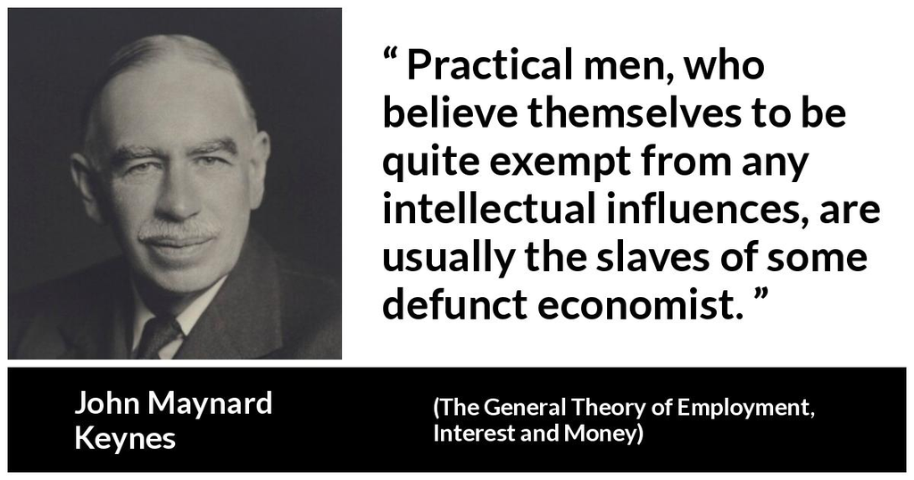

[figure not shown]

Recommended reading: [Esther Duflo - The Economist as Plumber (2017)](https://www.nber.org/papers/w23213)

## The MIDA framework (Lec 02 cont)

- The MIDA framework provides a structure for declaring and diagnosing any research design:
  - Model: Assumptions about how the world works (potential outcomes, relationships)
  - Inquiry: The specific question (estimand) we want to answer (e.g., ATE)
  - Data Strategy: How data are generated (sampling, treatment assignment)
  - Answer Strategy: The estimator used to answer the inquiry from the data (e.g., difference-in-means, regression)
- Using MIDA in code (with `DeclareDesign`) allows simulating the design to understand its properties (bias, power, etc.) *before* implementation

[figure not shown]

Source: [DeclareDesign](https://declaredesign.org/)

## Potential outcomes & causality (Lec 03)

- The Potential Outcomes (PO) framework is what we use for defining causal effects
  - For each unit $i$, there’s an outcome if treated ($Y_i(1)$) and an outcome if untreated ($Y_i(0)$)
  - The individual treatment effect is $\tau_i = Y_i(1) - Y_i(0)$
- The Fundamental Problem of Causal Inference states we only observe *one* potential outcome per unit ($Y_i = Y_i(1)Z_i + Y_i(0)(1-Z_i)$)
- Causality is inherently a missing data problem
- Our goal is often to estimate population averages, like the Average Treatment Effect (ATE): $ATE = E[Y_i(1) - Y_i(0)]$

[figure not shown]

[Wikipedia: Jorge Luis Borges - The garden of forking paths](https://en.wikipedia.org/wiki/The_Garden_of_Forking_Paths)

## Selection bias & SUTVA (Lec 03 cont)

- Selection bias arises when comparing groups that differ systematically *before* treatment (e.g., sicker people choosing hospitals), biasing simple comparisons
- Randomisation breaks the link between potential outcomes and treatment receipt, making groups comparable on average (in expectation) on all pre-treatment characteristics
- This allows unbiased ATE estimation via difference-in-means
- SUTVA (Stable Unit Treatment Value Assumption):
  - No interference between units (one unit’s treatment doesn’t affect another’s outcome)
  - Consistent treatment value (the treatment is the same for all units receiving it)

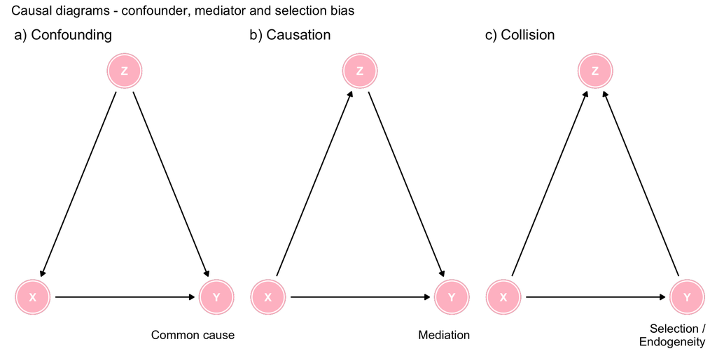

1. Confounding: Underlying illness ($Z$) causes both taking a specific drug ($X$) and experiencing a bad outcome ($Y$)
2. Mediation: Smoking ($X$) causes lung damage ($Z$), which then leads to breathing difficulties ($Y$)
3. Collision: A student’s talent ($X$) influences their grades ($Y$); both talent ($X$) and grades ($Y$) influence getting a scholarship ($Z$) – selecting only scholarship winners ($Z$) distorts the observed talent-grade relationship

## Selection bias (Lec 04)

1. Start with the observed difference in means: $E[Y_i|Z_i=1] - E[Y_i|Z_i=0]$
2. Substitute observed outcomes with potential outcomes based on treatment status: $= E[Y_i(1)|Z_i=1] - E[Y_i(0)|Z_i=0]$
3. Add and subtract the counterfactual for the treated group ($E[Y_i(0)|Z_i=1]$): $= E[Y_i(1)|Z_i=1] - E[Y_i(0)|Z_i=1] + E[Y_i(0)|Z_i=1] - E[Y_i(0)|Z_i=0]$
4. Group the terms: $= \{ E[Y_i(1)|Z_i=1] - E[Y_i(0)|Z_i=1] \} + \{ E[Y_i(0)|Z_i=1] - E[Y_i(0)|Z_i=0] \}$
5. Identify the components: $= ATT + \text{Selection Bias}$
   - Where ATT is the Average Treatment Effect on the Treated
   - And Selection Bias is $\{ E[Y_i(0)|Z_i=1] - E[Y_i(0)|Z_i=0] \}$, which is the difference in the *potential untreated outcomes* between those who selected treatment and those who did not
6. Under randomisation, $ATT = ATE$, and the selection bias term averages to zero
- Balance tests check pre-treatment covariate balance; useful diagnostic, but doesn’t guarantee balance on *unobservables*
- Beware common biases like attrition bias, survivorship bias, and post-treatment bias (controlling for mediators)

## Hypothesis testing: Neyman vs Fisher (Lec 05)

### Neyman Approach (ATE)

- Focuses on estimating the average effect in the population
- Tests hypotheses like $H_0: ATE = 0$ vs $H_a: ATE \neq 0$
- Uses test statistics (e.g, $t$-stat = estimate / SE) and $p$-values; rejects $H_0$ if $p$-value < $\alpha$
- Confidence Intervals provide a range of plausible values for the ATE
- Relies on large sample approximations (Central Limit Theorem)
- Considers Type I ($\alpha$) and Type II ($\beta$) errors; Power = 1 - $\beta$

### Fisher Approach (Randomisation Inference)

- Uses the random assignment process itself as the basis for inference
- Tests the sharp null hypothesis ($H_0: Y_i(1) = Y_i(0)$ for *all* $i$)
- Simulates all possible random assignments under $H_0$ to build a reference distribution
- The $p$-value is the proportion of simulated statistics as extreme as the observed one
- Requires fewer assumptions (no normality) and yields exact $p$-values; good for small samples (uses `ri2` package)

## Randomisation inference details (Lec 05 cont)

- The core idea of RI is to ask: “*Assuming the treatment had absolutely no effect on anyone (the sharp null), how likely were we to get a difference-in-means as large as the one we actually observed, just by the random chance of assignment?*”
- We generate the randomisation distribution by:
  - Assuming $H_0$ is true, so $Y_i(1)=Y_i(0)=Y_i^{obs}$ for all $i$
  - Recalculating the difference-in-means (or other test statistic) for many (or all) possible ways the units could have been randomly assigned to $Z=1$ and $Z=0$
  - Plotting these simulated differences
- The $p$-value is the fraction of simulated differences that are as large or larger in magnitude than our actual observed difference
- This avoids assumptions about the distribution of outcomes needed for t-tests

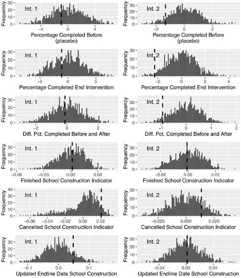

Source: [Myself (2020) 😂](https://journals.sagepub.com/doi/full/10.1177/2053168020914444)

## Key experimental findings (Lec 06)

- Discussed influential studies applying experimental methods:
  - Kalla & Broockman (2015): Used a field experiment (blocked randomisation) to show revealing donor status significantly increased political access to US congressional officials
  - Bertrand & Mullainathan (2004): Employed a correspondence study (field experiment) randomising names on CVs, finding significant callback gaps favouring White-sounding names in the US labour market
  - Chattopadhyay & Duflo (2004): Leveraged a natural experiment (randomised council seat reservations in India) showing female leaders prioritised different public goods (water vs roads) compared to male leaders

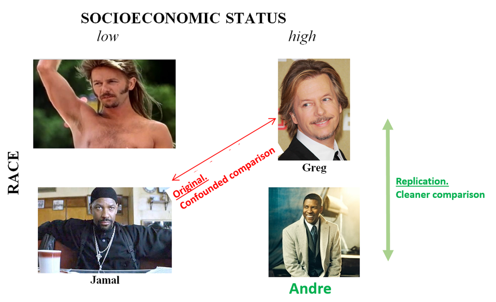

Source: [Data Collada (2016)](https://datacolada.org/51)

# Design Challenges & Solutions 🛠️

## Blocking and clustering (Lec 07 & 08)

### Blocking

- Group units by pre-treatment covariates ($X$) related to outcome ($Y$); randomise *within* blocks
- Increases precision (removes between-block variance), ensures balance on $X$
- Include block fixed effects or use interaction estimators (`lm_lin`)

### Clustering

- Treatment assigned at group level (village, school); outcomes measured at individual level
- Often necessary due to practical constraints or spillovers
- **Challenge:** Intra-Cluster Correlation (ICC) violates independence ($\rho = \frac{\sigma^2_{between}}{\sigma^2_{between} + \sigma^2_{within}}$)

### Clustering Consequences & Power

- Use Cluster-Robust Standard Errors (CRSE) (`estimatr::lm_robust(..., clusters = ...)`), requires sufficient clusters
- Power analysis must account for ICC; driven more by number of clusters
- Improve designs via pair-matching or blocking at the cluster level

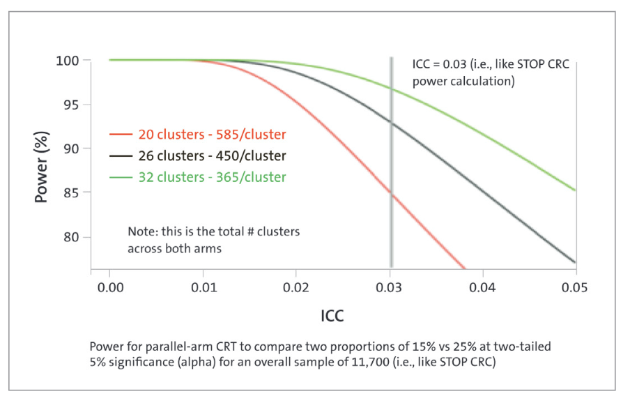

Source: [NIH Collaboratory (2020)](https://dcricollab.dcri.duke.edu/sites/NIHKR/KR/Intraclass_Correlation_Coefficient_Cheat_Sheet_March_15_2020.pdf)

## Power analysis principles (Lec 08 cont)

- Statistical power is the probability of correctly rejecting a false null hypothesis (detecting a true effect)
- Conventionally aim for power $\ge 0.80$
- Power depends on:
  - Effect size: Larger effects are easier to detect
  - Sample size ($N$): Larger $N$ increases power
  - Significance level ($\alpha$): Lower $\alpha$ reduces power
  - Outcome variance ($\sigma^2$): Lower variance increases power
  - Proportion treated: Power is maximised with equal group sizes (50/50 split)
  - Design features: Blocking increases power; clustering decreases power (must use $n_{ESS}$)
- Conduct power analysis *before* the experiment using tools like `DeclareDesign` or power calculators, making reasonable assumptions about effect size and variance

## One-sided non-compliance (Lec 09)

- Some assigned to treatment ($Z=1$) don’t receive it ($D=0$), but control compliance ($Z=0 \implies D=0$) is perfect
- Compliers ($D_i(1)=1, D_i(0)=0$) and Never-takers ($D_i(1)=0, D_i(0)=0$)
- Intent-to-Treat (ITT) effect ($E[Y|Z=1] - E[Y|Z=0]$) estimates the effect of *assignment*; it’s unbiased but diluted
- Complier Average Causal Effect (CACE/LATE) ($E[Y_i(1) - Y_i(0) | D_i(1)>D_i(0)]$) estimates the effect of treatment *on compliers*
- Estimation uses Instrumental Variables (IV) / 2SLS, with assignment ($Z$) as instrument for treatment receipt ($D$)
- $CACE = ITT_Y / ITT_D$
- Requires relevance, exclusion, independence assumptions

Compliance types

|  | Wᵢ(0) = 0 | Wᵢ(0) = 1 |
| --- | --- | --- |
| Wᵢ(1)=0 | never-taker | defier |
| Wᵢ(1)=1 | complier | always-taker |

## Two-sided non-compliance (Lec 10)

- Non-compliance occurs in both arms: some $Z=1$ don’t get $D=1$; some $Z=0$ *do* get $D=1$ (e.g., control group finds alternative access)
- Adds potential for Always-takers ($D_i(1)=1, D_i(0)=1$) and Defiers ($D_i(1)=0, D_i(0)=1$)
- Observed groups become mixtures of compliance types
- Requires the Monotonicity Assumption (assume no Defiers) to identify CACE; this implies $D_i(1) \ge D_i(0)$ for all $i$
- Estimation still uses IV/2SLS ($CACE = ITT_Y / ITT_D$)
- Always-takers don’t bias the IV estimate under monotonicity

[figure not shown]

Source: [Facure (2022)](https://matheusfacure.github.io/python-causality-handbook/09-Non-Compliance-and-LATE.html)

## Attrition: missing outcome data (Lec 11)

- Attrition involves missing outcome data post-randomisation (e.g., participants drop out)
- Bias occurs if attrition is non-random (differential attrition related to treatment or potential outcomes)
- Handling Options:
  - Assume MCAR (unlikely); analyse complete cases (reduces power)
  - Assume MAR / Conditional Ignorability ($MIPO|X$): Missingness depends only on *observed* pre-treatment $X$; use Inverse Probability Weighting (IPW) to upweight observed units similar to missing ones
  - Assume MNAR: Missingness depends on unobservables; use Bounds Analysis to estimate range of possible ATEs under worst-case (Manski bounds) or monotonicity assumptions (Lee bounds)

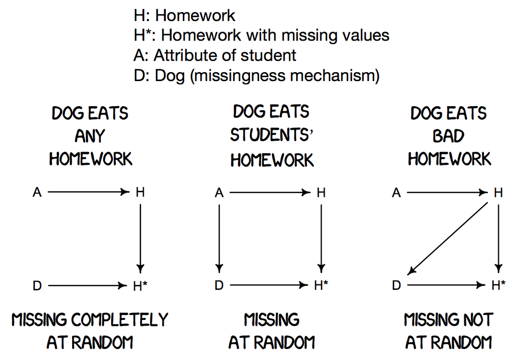

Source: [McElreath on X (2019)](https://x.com/rlmcelreath/status/1101435108995805185)

## Ethics in research design (Lec 12)

- Ethical conduct is integral to good science
- Core Principles from the Belmont Report:
  - Respect for Persons: Requires informed consent, autonomy, and protection for vulnerable groups
  - Beneficence: Involves minimising harm and maximising potential benefits through careful risk-benefit assessment; Equipoise (genuine uncertainty) is key
  - Justice: Demands fair participant selection and equitable distribution of research burdens/benefits
- Practical implementation involves Institutional Review Boards (IRBs), clear consent processes, data protection, and considering staff/community well-being
- Adaptive designs can enhance ethics by allocating more participants to effective treatments sooner

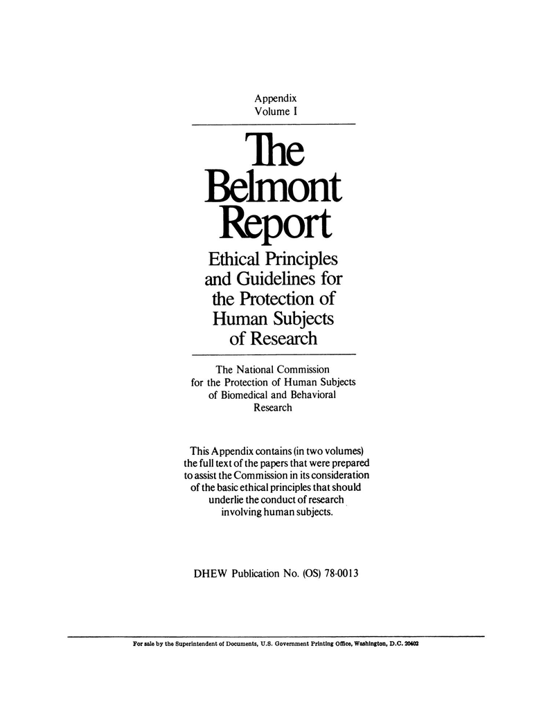

Source: [Belmont Report (1979)](https://www.hhs.gov/ohrp/regulations-and-policy/belmont-report/read-the-belmont-report/index.html)

## Six components of a `DeclareDesign` study (Lec 13)

- DeclareDesign formalises research plans using six key components, specified using `declare_*` functions:
  - Population: Defines units and their characteristics (`declare_model`)
  - Potential outcomes: Specifies how outcomes depend on treatments (`declare_model`)
  - Sampling strategy: How units are selected (`declare_sampling`)
  - Assignment: How units are assigned to treatment (`declare_assignment`)
  - Estimand: The target quantity of interest (`declare_inquiry`)
  - Estimator: The procedure/model used for estimation (`declare_estimator`)
- The `DesignLibrary` package provides pre-built templates for common designs

[figure not shown]

Source: [DeclareDesign](https://declaredesign.org/)

## Pre-analysis plans (PAPs) in practice (Lec 14)

- PAPs detail the research plan (hypotheses, design, analysis) *before* data analysis
- Aim to increase transparency, reduce bias (p-hacking, HARKing), enhance credibility
- Stemmed from reproducibility crisis
- Main components: Motivation, Hypotheses, Population/Sampling, Intervention, Outcomes/Covariates, Randomisation, Analysis Plan (estimators, SEs, power, missing data, subgroups), Implementation details
- Should distinguish confirmatory (pre-specified) from exploratory analyses
- Pros: Credibility, transparency, limits researcher degrees of freedom
- Cons: Time-consuming, potentially inflexible (mitigated by allowing pre-specified exploratory analysis or clear justifications for deviations)
- Registries like OSF, AEA, EGAP host PAPs
- SOPs (Standard Operating Procedures) offer a potentially more flexible alternative but are less common

# Advanced Methods & Applications 🔬

## Natural & quasi-experiments (Lec 15)

- Used when RCTs aren’t feasible/ethical, leveraging “as-if” random assignment
- Natural Experiments rely on assignment outside researcher control (e.g, lotteries); require strong exogeneity arguments
- Quasi-Experiments are a broader category; common designs include:
  - Regression Discontinuity (RDD): Exploits sharp cut-off rules (e.g., Mignozzetti et al); assumes continuity of potential outcomes at the cut-off
  - Difference-in-Differences (DID): Compares changes over time for treated vs control (e.g., Card & Krueger); assumes parallel trends in the absence of treatment
- Validity depends heavily on the plausibility of underlying assumptions

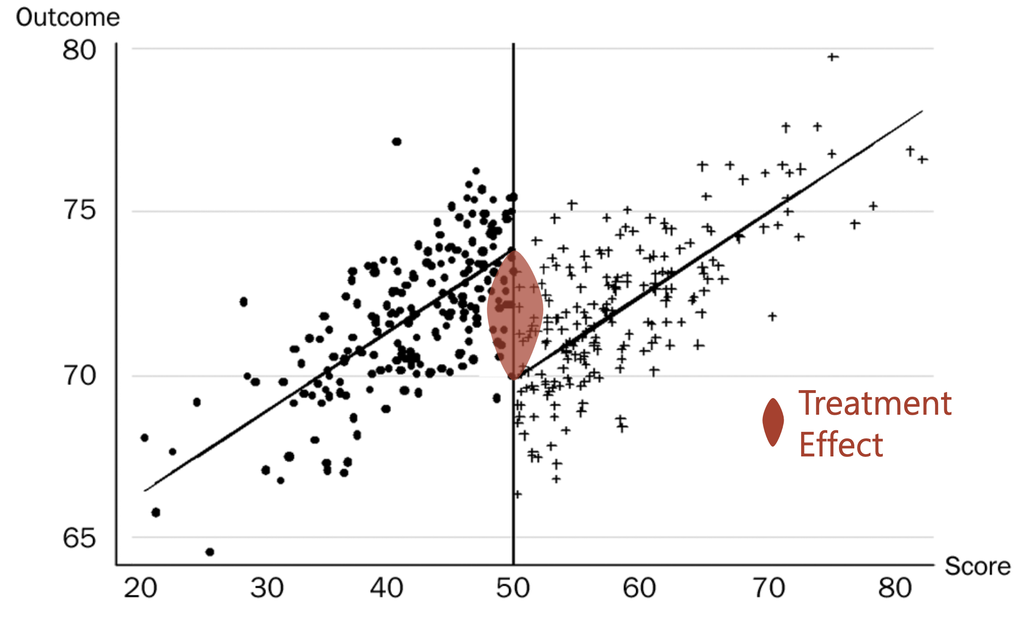

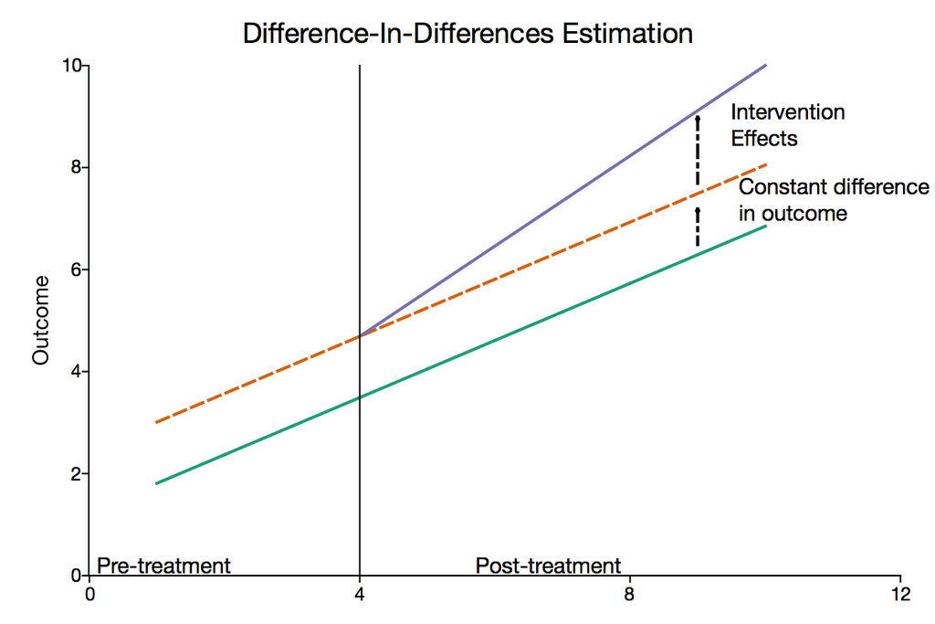

## Interference & spillovers (Lec 16)

- Interference occurs when one unit’s treatment affects another’s outcome (a SUTVA violation); common in social/network settings
- Standard ATE estimates become biased
- Requires expanding potential outcomes notation (e.g, $Y_{i}(Z_i, Z_{-i})$)
- Designs to address/estimate interference:
  - Clustered randomisation: Randomise at a level high enough to contain spillovers
  - Multi-level designs: Randomise at multiple levels (e.g., household & individual) to separate direct/indirect effects

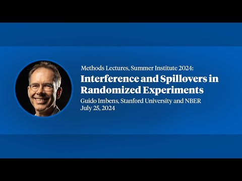

[YouTube video on spillovers](https://www.youtube.com/watch?v=i5kyzT_CpwQ)

## Heterogeneous treatment effects (HTE) (Lec 18)

- Effects often vary; ATE is just the average; understanding variability is key
- Challenge: $Var(\tau)$ depends on unidentifiable $Cov(Y(1), Y(0))$
- Exploring HTE:
  - Treatment-by-Covariate Interactions (CATEs): Estimate ATE within subgroups based on pre-treatment $X$; use regression interactions ($Y \sim Z * X$); Caution: Correlational re: HTE source; multiple comparisons risk
  - Treatment-by-Treatment Interactions (Factorial Designs): Experimentally manipulate multiple factors ($Z_1, Z_2$); allows causal inference about interactions; requires larger N
- Beware the multiple comparisons problem when testing many subgroups; use corrections (Bonferroni) or pre-specification

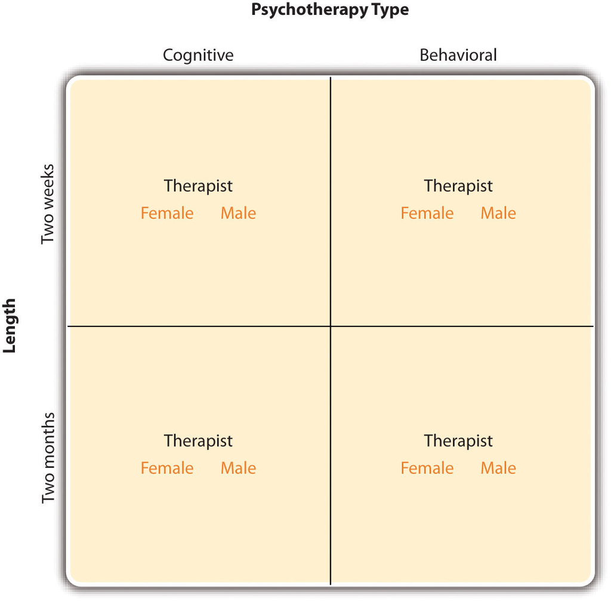

Source: [University of Minnesota (2020)](https://courses.lumenlearning.com/suny-psychologyresearchmethods/chapter/8-2-multiple-independent-variables/)

## Mediation analysis (Lec 20)

- Seeks to understand *how* $Z$ affects $Y$ via mediator $M$ ($Z \to M \to Y$)
- Traditional regression methods are often biased due to $M \leftrightarrow Y$ confounding (omitted variables affecting both $M$ and $Y$)
- Potential outcomes approach reveals fundamental identification problem requiring strong ‘sequential ignorability’ assumptions ($M$ is ‘as-if’ random conditional on $Z$ and $X$)
- Randomising $Z$ alone is insufficient or impossible
- Using $Z$ as an IV for $M$ requires the strong exclusion restriction (no direct $Z \leftrightarrow Y$ path), often violated
- Implicit Mediation is a robust design-based alternative:
  - Experimentally vary treatment components ($Z$ vs $Z'$)
  - Compare effects of different bundles to infer mechanism importance without measuring $M$

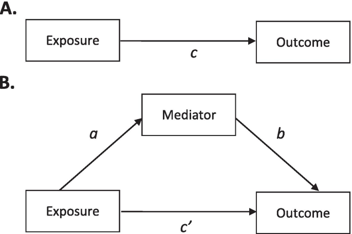

Source: [Rijnhart et al (2021)](https://bmcmedresmethodol.biomedcentral.com/articles/10.1186/s12874-021-01426-3)

## Survey experiments (Lec 21 & 22)

### Survey Experiments (Lec 21)

- Random assignment embedded within survey instruments
- Ideal for studying attitudes, preferences, information effects
- Common designs: Question wording/framing, order effects, vignettes
- Trade-offs: High internal validity vs potential external validity/demand effect concerns

### Sensitive Topics (Lec 22)

- Challenge: Social desirability bias
- Goal: Elicit truthful responses while protecting privacy
- Techniques: List Experiment, Randomised Response (RRT), Endorsement Experiment, Conjoint Analysis

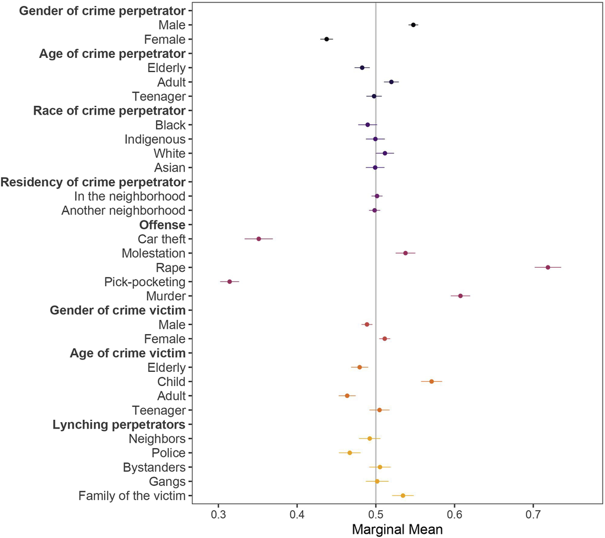

Source: [Freire & Skarbek (2022)](https://journals.sagepub.com/doi/10.1177/20531680221150389)

## Survey experiments: validation & design (Lec 21 cont)

- Ensuring construct validity (manipulating what you intend):
  - Pilot testing treatments before main study
  - Manipulation checks (post-treatment questions assessing if manipulation worked)
  - Placebo conditions (similar task/info but without key manipulation)
  - Non-equivalent outcomes (outcomes that *shouldn’t* be affected)
- Design considerations:
  - Comparability across conditions (length, complexity)
  - Realism of vignettes/stimuli
  - Respondent burden and attention (timers, forced exposure)
  - Device compatibility (mobile vs desktop)

## Sensitive survey techniques details (Lec 22 cont)

- List Experiment: Compare mean count between T (list + sensitive item) and C (list only); difference estimates prevalence; assumes no design effects/no liars; watch for floor/ceiling effects
- RRT: Respondent uses random device (coin flip) to determine whether to answer truthfully or give fixed response; known probabilities allow estimation; can be confusing for respondents but often performs well in validation
- Endorsement Experiment: Randomly associate policy/statement with endorsing group; difference in support reveals implicit attitude towards endorser; analysis complex with multiple endorsers
- Conjoint Analysis: Respondents choose between profiles with multiple randomised attributes; estimates importance of each attribute (including sensitive ones) via trade-offs; powerful but complex design/analysis

# Discussions & Integration 🌍

## Paper discussions (Lec 06, 17, 19, 23)

### Foundational Ideas & Design

- Lec 06: Kalla & Broockman (access), Bertrand & Mullainathan (discrimination), Chattopadhyay & Duflo (representation)
  - Classic examples of field & natural experiments demonstrating core concepts
- Lec 17: Centola (networks/contagion), Paluck (network intervention/climate), Gerber & Green (GOTV/interference/IV)
  - Focused on exploring interference, network structure, and spillover effects experimentally and analytically

### Identification & Complex Settings

- Lec 19: Munshi (networks/IV/FE), Miguel & Kremer (externalities/cluster RCT/spillovers)
  - Showcased clever identification strategies using IVs and cluster-randomisation for observational data and spillovers
- Lec 23: Druckman (list/sensitive), Blair (list+endorsement/sensitive), Rosenfeld (validation/sensitive), Freire & Skarbek (conjoint/sensitive)
  - Illustrated application and validation of methods for sensitive topics

## Integration of research findings (Lec 24)

- Generalising results (extrapolation) is challenging; distinguish Sample ATE (SATE) from Population ATE (PATE); PATE estimation adds sampling uncertainty
- The Bayesian framework formally updates prior beliefs with new evidence, can incorporate beliefs about potential bias (e.g., sampling bias); posterior is precision-weighted average
- Meta-Analysis pools results from multiple studies
  - Fixed Effects assumes one true effect; weights by precision ($1/SE^2$)
  - Random Effects allows true effect to vary across studies (more realistic); accounts for between-study heterogeneity
  - Beware publication bias and study heterogeneity

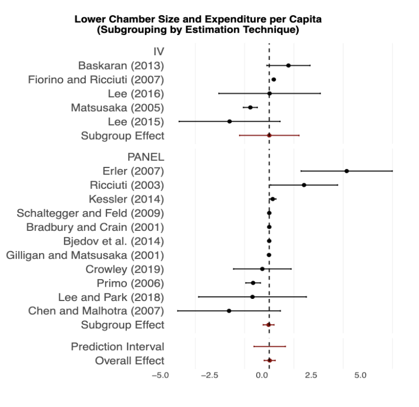

Source: [Freire et al (2022)](https://doi.org/10.1017/S0007123422000552)

## Generalisation & meta-analysis details (Lec 24 cont)

- PATE standard error includes sampling variance: $SE(\widehat{PATE}) = \sqrt{ \frac{Var(Y_i(1))}{m} + \frac{Var(Y_i(0))}{N-m} }$
- Bayesian updating combines prior precision ($\rho_{prior}$) and data precision ($\rho_{data}$) for posterior precision ($\rho_{posterior} = \rho_{prior} + \rho_{data}$)
- Posterior mean is precision-weighted average: $\mu_{posterior} = \frac{\rho_{prior} \mu_{prior} + \rho_{data} x_e}{\rho_{posterior}}$
- Incorporating bias ($B \sim N(\beta, \sigma^2_B)$) reduces effective data precision: $\rho_{effective\_data} = \frac{1}{\sigma^2_B + \sigma^2_{xe}}$
- Meta-analysis requires careful study selection (PRISMA), data extraction, and choice between fixed/random effects models; meta-regression explores heterogeneity sources

## Wrapping up

- Phew, that was a lot of content! 😅
- We’ve discussed from basic experimental design (MIDA, PO) through implementation challenges (compliance, attrition, ethics, interference) to advanced analysis (HTE, mediation, quasi-methods) and synthesis (meta-analysis)
- Key theme: Understanding assumptions, potential biases, and choosing appropriate experimental designs and methods
- Experiments are amazing 🤩! But they require careful thought and execution
- Thank you for your engagement throughout the course 🙌
- Any questions?

[figure not shown]

# Thank you for your attention! 🙏